# Reproducible Research[Course Project-1]

Sandeep Anand

February 12, 2017

## Loading and preprocessing the data

```r
# Extract/Unzip the Dataset
library(tools)
path = "./"
setwd("C:/Reproducible Research")
l = list.files(path = path)
for (val in l)
{
  if (file_ext(val) == "zip"){
    unzip(zipfile = val,exdir = "./dataset")
  }
}

# Process it
newpath = "./dataset/"
csvfile = list.files(path = newpath)
filepath = paste(newpath,csvfile, sep = "")
activity<-read.csv(file = filepath, head=TRUE,sep = ",")
```

## What is mean total number of steps taken per day ?

You can also embed plots

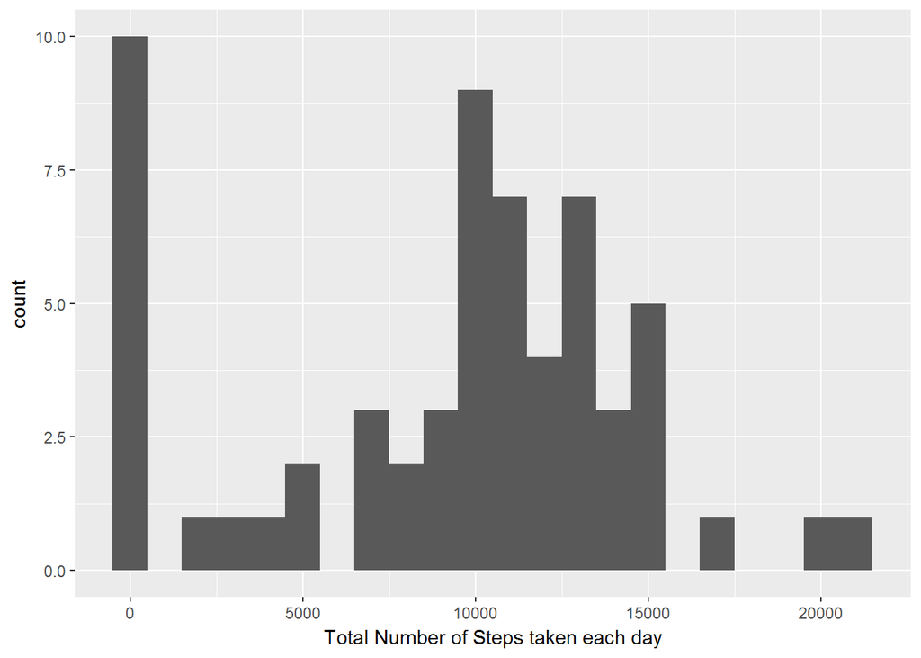

```r
library(ggplot2)
total.steps<-tapply(activity$steps,activity$date,sum,na.rm=TRUE)
qplot(total.steps, binwidth = 1000, xlab = "Total Number of Steps taken each day")
```

## What is the average daily activity pattern?

You can also embed plots

```r
library(ggplot2)
mean(total.steps, na.rm = TRUE)
```

```
## [1] 9354.23
```

```r
median(total.steps, na.rm = TRUE)
```

```
## [1] 10395
```

## Time series plot of the average number of steps taken

1. Make a time series plot (i.e. type = “l”) of the 5-minute interval (x-axis) and the average number of steps taken, averaged across all days (y-axis)
2. Which 5-minute interval, on average across all the days in the dataset, contains the maximum number of steps?

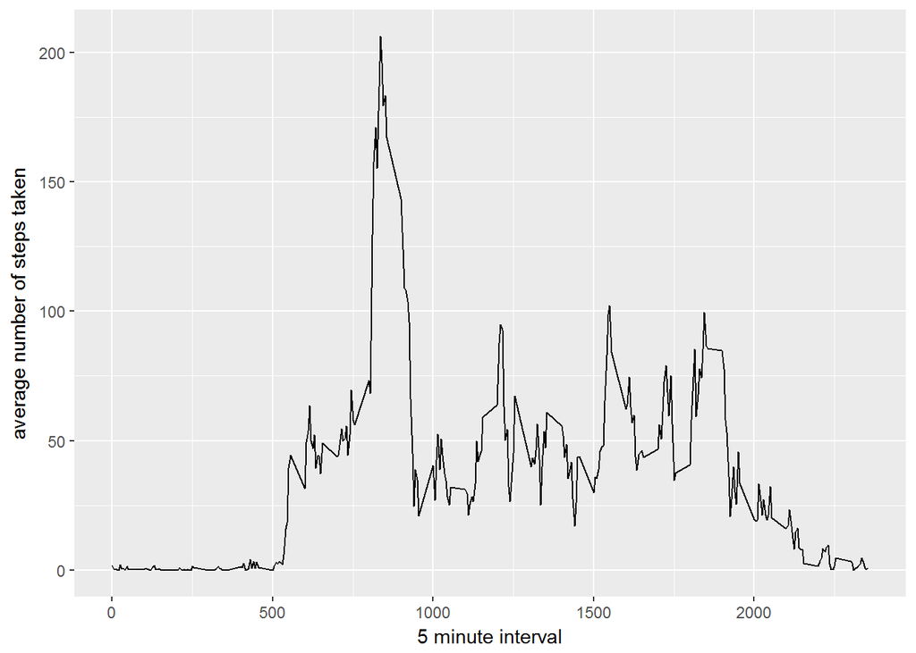

```r
library(ggplot2)
steps_byinterval <- aggregate(steps ~ interval, activity, mean)

ggplot(data = steps_byinterval, aes(x = interval, y=steps)) + geom_line() + xlab("5 minute interval") + ylab("average number of steps taken")
```

```r
steps_byinterval[which.max(steps_byinterval$steps),]
```

```
##     interval    steps
## 104      835 206.1698
```

## Imputing missing values

Calculate and report the total number of missing values in the dataset (i.e. the total number of rows with NAs)

```r
missingvals<-is.na(activity$steps)
table(missingvals)
```

```
## missingvals
## FALSE  TRUE
## 15264  2304
```

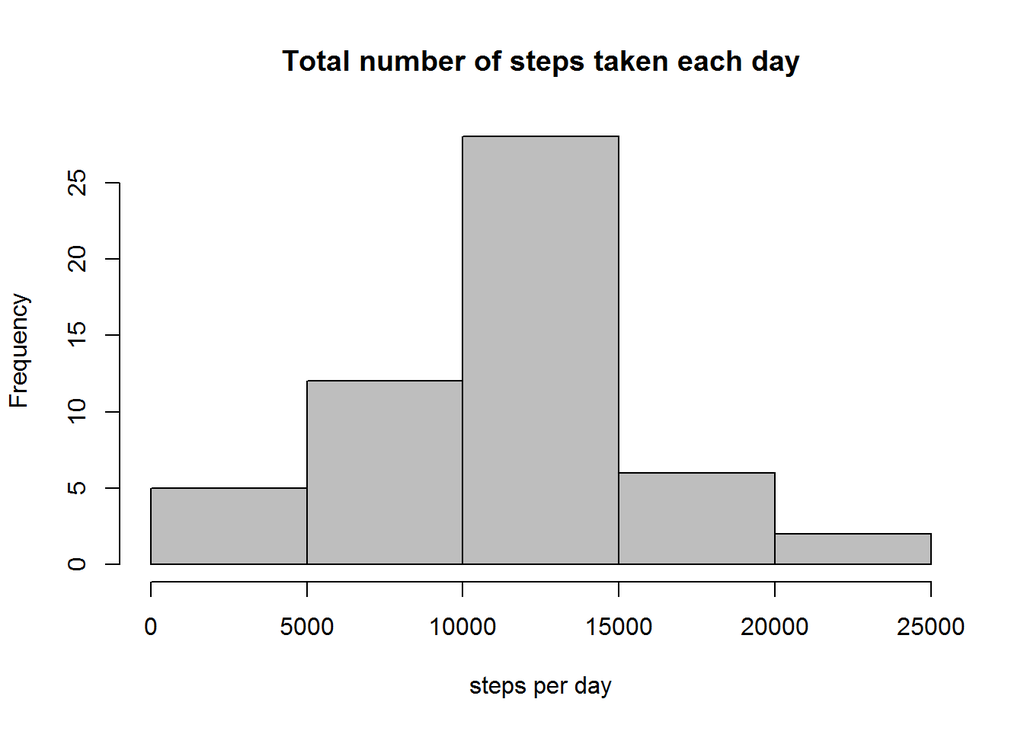

```r
for (i in 1:nrow(activity)){
  if(is.na(activity$steps[i])){
    val<- steps_byinterval$steps[which(steps_byinterval$interval == activity$interval[i])]
    activity$interval[i] <- val
  }
}

# Create the new data set , Aggregate the steps per day with the imputed values
steps_per_day_impute <- aggregate(steps ~ date, activity, sum)

# Getting the histogram for the value
hist(steps_per_day_impute$steps , main = "Total number of steps taken each day", xlab = "steps per day", col = "gray")
```

```r
# Calculate and report the mean and median total number of steps taken per day

mean(steps_per_day_impute$steps)
```

```
## [1] 10766.19
```

```r
median(steps_per_day_impute$steps)
```

```
## [1] 10765
```

#### Clearly the Mean and Median Values have **“CHANGED”** from the Previous values which were not Imputed

## Are there differences in activity patterns between weekdays and weekends?

1. For this part the weekdays() function may be of some help here. Use the dataset with the filled-in missing values for this part.
2. Create a new factor variable in the dataset with two levels - “weekday” and “weekend” indicating whether a given date is a weekday or weekend day.

Make a panel plot containing a time series plot (i.e. type = “l”) of the 5-minute interval (x-axis) and the average number of steps taken, averaged across all weekday days or weekend days (y-axis). See the README file in the GitHub repository to see an example of what this plot should look like using simulated data.

#### Create a function if the date in a weekday or a weekend

```r
weekday<-function(dateval) {
  wd <- weekdays(as.Date(dateval, '%Y-%m-%d'))
  if (!(wd == 'Saturday' || wd == 'Sunday')){
    x <- 'Weekday'
  } else {
    x <- 'Weekend'
  }
}
```

#### Now Apply the function to the new dataset

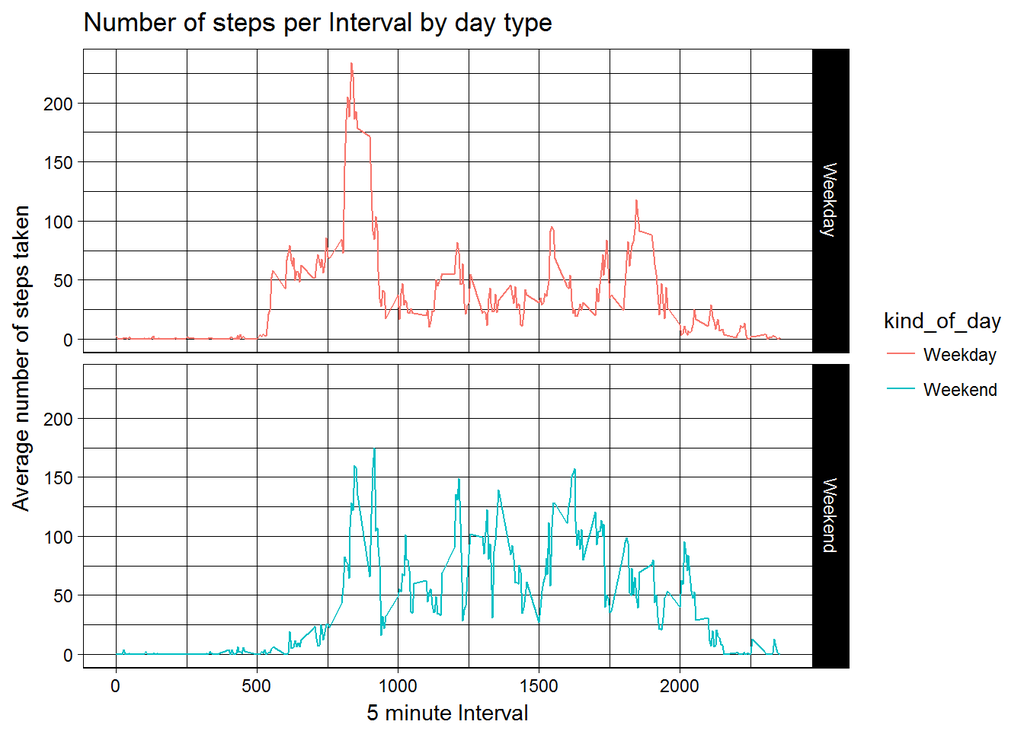

```r
activity$kind_of_day <- as.factor(sapply(activity$date, weekday))

library(ggplot2)

steps_per_day_impute<-aggregate(steps ~ interval+kind_of_day, activity, mean)

plt<-ggplot(steps_per_day_impute, aes(interval, steps)) +
      geom_line(stat = "identity", aes(colour = kind_of_day)) + theme_linedraw() +
      facet_grid(kind_of_day ~.,scales = "fixed", space = "fixed") +
      labs(x = "5 minute Interval", y = "Average number of steps taken") +
      ggtitle("Number of steps per Interval by day type")

print(plt)
```